# Reproduction number daily

Jan Netík

#### Report generated: 2020-03-20 11:42:59

#### Data source: https://onemocneni-aktualne.mzcr.cz/covid-19

Quick numbers

| infected | tested | recovered |
| --- | --- | --- |
| 774 | 11619 | 3 |

Cumulative number of positive cases

| date | positive |
| --- | --- |
| 2020-03-01 | 3 |
| 2020-03-02 | 3 |
| 2020-03-03 | 5 |
| 2020-03-04 | 5 |
| 2020-03-05 | 8 |
| 2020-03-06 | 19 |
| 2020-03-07 | 26 |
| 2020-03-08 | 32 |
| 2020-03-09 | 38 |
| 2020-03-10 | 63 |
| 2020-03-11 | 94 |
| 2020-03-12 | 116 |
| 2020-03-13 | 141 |
| 2020-03-14 | 189 |
| 2020-03-15 | 298 |
| 2020-03-16 | 383 |
| 2020-03-17 | 450 |
| 2020-03-18 | 560 |
| 2020-03-19 | 765 |
| 2020-03-20 | 774 |

For following analyses, we use *limited dataset* from outbreak beginning to last complete day (usually, *fully closed* data are given around 9 AM *the day after*). Please, **check the validity by hand**.

Last complete day used for all following analyses

| date | positive |
| --- | --- |
| 2020-03-19 | 765 |

## Simple fitting

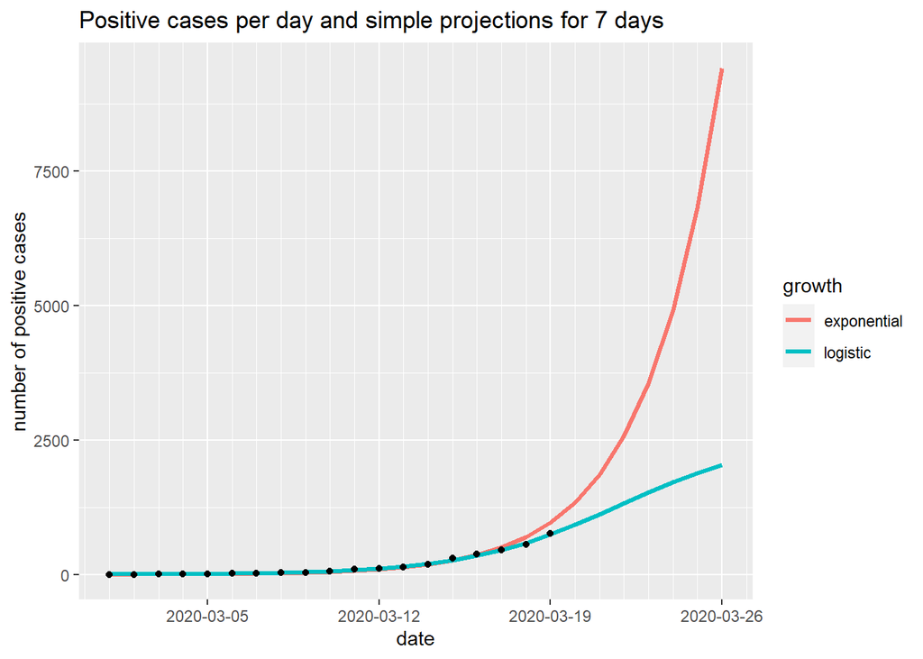

## Time-dependent reproduction number estimate $R_t$

### Probably best results is from model using log normal SI distribution (see below)

Based on 7-day sliding window and serial interval parameters from https://doi.org/10.1101/2020.02.19.20025452.

> Mean and standard deviation are 3.96 (95% CI 3.53-4.39) and 4.75 (95% CI 4.46-5.07) days, respectively, with 12.6% of reports indicating pre-symptomatic transmission.

Here are the plots and table further detailing $R_t$ by each window (denoted with day-day range):

```
## Default config will estimate R on weekly sliding windows.
##     To change this change the t_start and t_end arguments.
```

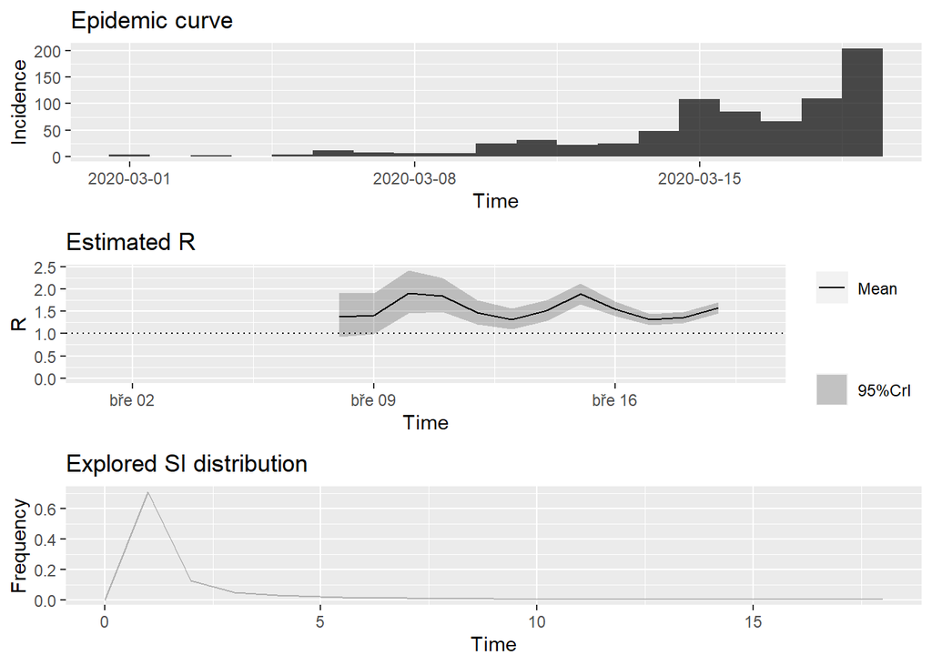

|  | R mean | R standard deviation | 2.5th percentile | 50th percentile | 97.5th percentile |
| --- | --- | --- | --- | --- | --- |
| **2–8** | 1.379 | 0.2518 | 0.9305 | 1.364 | 1.915 |
| **3–9** | 1.415 | 0.2359 | 0.9912 | 1.402 | 1.913 |
| **4–10** | 1.914 | 0.2491 | 1.457 | 1.903 | 2.432 |
| **5–11** | 1.854 | 0.1954 | 1.491 | 1.847 | 2.256 |
| **6–12** | 1.469 | 0.1408 | 1.207 | 1.465 | 1.758 |
| **7–13** | 1.32 | 0.119 | 1.097 | 1.316 | 1.563 |
| **8–14** | 1.518 | 0.1185 | 1.294 | 1.515 | 1.759 |
| **9–15** | 1.888 | 0.1155 | 1.668 | 1.885 | 2.121 |
| **10–16** | 1.558 | 0.08376 | 1.398 | 1.557 | 1.726 |
| **11–17** | 1.316 | 0.06683 | 1.189 | 1.315 | 1.45 |
| **12–18** | 1.366 | 0.0632 | 1.245 | 1.365 | 1.492 |
| **13–19** | 1.578 | 0.06191 | 1.459 | 1.578 | 1.702 |

Here are the parameters for log normal and gamma distributions (fitted on truncated (>0) data) from aforementioned article. Note that log normal fit original distribution better (see AIC).

| Distribution | Mean/Shape [95% CI] | SD/Scale [95% CI] | AIC |  |
| --- | --- | --- | --- | --- |
| Lognormal | 2.02 [1.76,2.31] | 2.78 [2.39,3.25] | 1,886.73 |  |
| Gamma | 1.46 [1.38,1.54] | 0.78 [0.72,0.84] | 1,898.63 |  |

## Log normal

```
## Default config will estimate R on weekly sliding windows.
##     To change this change the t_start and t_end arguments.
```

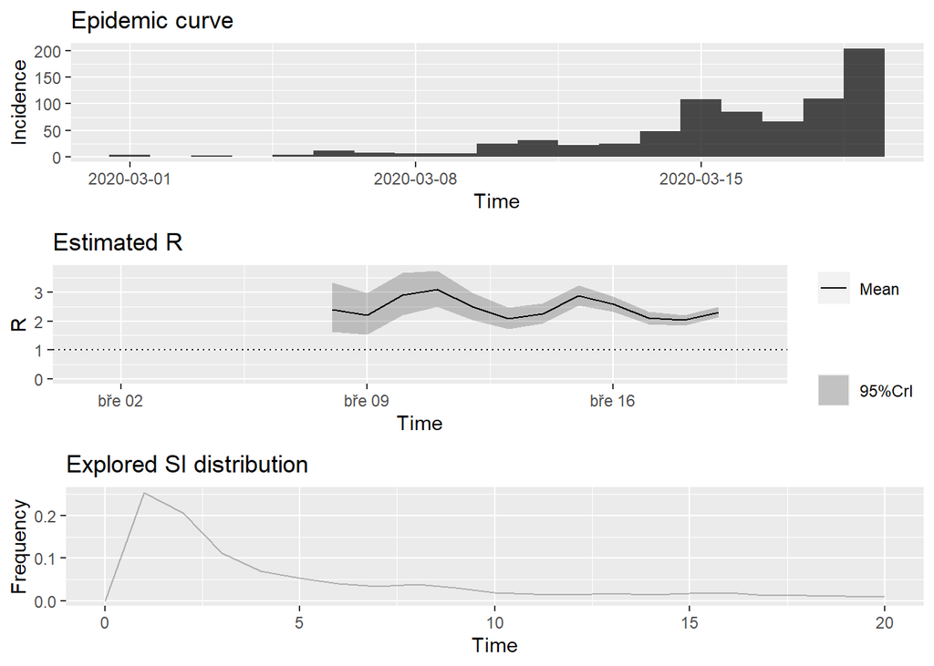

|  | R mean | R standard deviation | 2.5th percentile | 50th percentile | 97.5th percentile |
| --- | --- | --- | --- | --- | --- |
| **2–8** | 2.405 | 0.4391 | 1.623 | 2.378 | 3.339 |
| **3–9** | 2.205 | 0.3676 | 1.545 | 2.185 | 2.982 |
| **4–10** | 2.9 | 0.3775 | 2.207 | 2.883 | 3.685 |
| **5–11** | 3.092 | 0.326 | 2.487 | 3.081 | 3.763 |
| **6–12** | 2.497 | 0.2392 | 2.051 | 2.49 | 2.987 |
| **7–13** | 2.089 | 0.1883 | 1.736 | 2.083 | 2.474 |
| **8–14** | 2.254 | 0.176 | 1.923 | 2.25 | 2.612 |
| **9–15** | 2.881 | 0.1763 | 2.546 | 2.877 | 3.237 |
| **10–16** | 2.588 | 0.1391 | 2.322 | 2.586 | 2.868 |
| **11–17** | 2.104 | 0.1068 | 1.9 | 2.102 | 2.318 |
| **12–18** | 2.031 | 0.09399 | 1.851 | 2.03 | 2.219 |
| **13–19** | 2.316 | 0.09084 | 2.141 | 2.315 | 2.497 |

## Gamma

```
## Default config will estimate R on weekly sliding windows.
##     To change this change the t_start and t_end arguments.
```

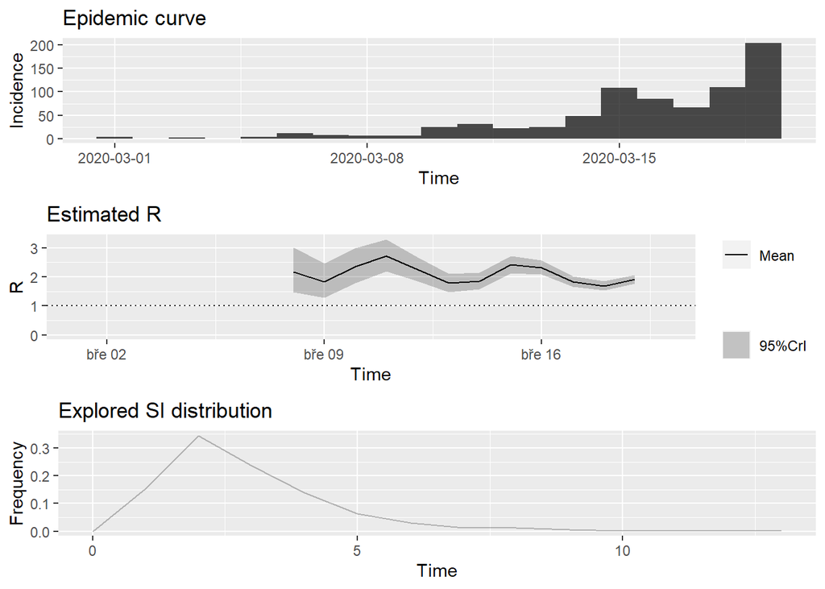

|  | R mean | R standard deviation | 2.5th percentile | 50th percentile | 97.5th percentile |
| --- | --- | --- | --- | --- | --- |
| **2–8** | 2.177 | 0.3975 | 1.469 | 2.153 | 3.023 |
| **3–9** | 1.823 | 0.3038 | 1.276 | 1.806 | 2.464 |
| **4–10** | 2.35 | 0.3059 | 1.789 | 2.337 | 2.986 |
| **5–11** | 2.71 | 0.2857 | 2.179 | 2.7 | 3.298 |
| **6–12** | 2.244 | 0.215 | 1.843 | 2.237 | 2.685 |
| **7–13** | 1.782 | 0.1607 | 1.481 | 1.777 | 2.111 |
| **8–14** | 1.845 | 0.144 | 1.573 | 1.841 | 2.137 |
| **9–15** | 2.414 | 0.1477 | 2.133 | 2.411 | 2.712 |
| **10–16** | 2.316 | 0.1245 | 2.079 | 2.314 | 2.567 |
| **11–17** | 1.837 | 0.09326 | 1.659 | 1.836 | 2.024 |
| **12–18** | 1.686 | 0.07801 | 1.536 | 1.685 | 1.842 |
| **13–19** | 1.91 | 0.07493 | 1.766 | 1.909 | 2.06 |